# Exploratory Bar Graphs - Whale’s Tale

Sam Pritchard

December 20, 2017

```
## [1] "sum of Total.Sales is 4514974.5904"
```

# SUPPLIERS

In $ the bottom 25% brought in $10,671 in 2017, which is 109 suppliers

```
##               Supp.By.Year            Supplier Year Total.Sales Perc.Whole
## 1             PAPYRUS 2017             PAPYRUS 2017    96955.62        4.3
## 2          MICHOU INC 2017          MICHOU INC 2017    70305.25        3.1
## 3 OLD WORLD CHRISTMAS 2017 OLD WORLD CHRISTMAS 2017    66670.94        3.0
## 4             FIREFLY 2017             FIREFLY 2017    61393.74        2.7
## 5     CHRONICLE BOOKS 2017     CHRONICLE BOOKS 2017    50346.18        2.2
## 6       ACOMO JEWELRY 2017       ACOMO JEWELRY 2017    41578.14        1.9
```

```
## [1] 55
```

```
## [1] 74.2
```

```
## [1] 84.8
```

```
## [1] 91.6
```

```
## [1] 95.8
```

```
## [1] 0
```

```
## [1] 0
```

| Supplier | 2017 | 2016 | Growth | Perc.Growth |
| --- | --- | --- | --- | --- |
| ANDREA MENGHETTI | 246.00 | 769.60 | -523.60 | -68% |
| NELSON LINE | 245.33 | 1267.35 | -1022.02 | -80.6% |
| JEREMY SINKUS | 245.00 | 344.00 | -99.00 | -28.8% |
| OBRIEN FINE ART & DESIGN | 239.50 | 1631.85 | -1392.35 | -85.3% |
| SUSAN FAIRGRIEVE DESIGN | 225.00 | 28.00 | 197.00 | 703.6% |
| CHAVEZ FOR CHARITY | 220.00 | 1023.00 | -803.00 | -78.5% |
| Z-ROBERT HELD ART GLASS | 220.00 | 683.00 | -463.00 | -67.8% |
| POST OFFICE | 219.72 | 201.38 | 18.34 | 9.1% |
| WOODCUTTS | 219.00 | 1773.35 | -1554.35 | -87.7% |
| NANCIE DUNN | 216.15 | 707.00 | -490.85 | -69.4% |
| TOWN TILES | 207.20 | 175.91 | 31.29 | 17.8% |
| HOMART | 202.95 | 519.20 | -316.25 | -60.9% |
| PRAOLS STORY BRACELETS | 200.00 | 1618.99 | -1418.99 | -87.6% |
| THE GIRL WITH A PEARL | 190.20 | 1543.00 | -1352.80 | -87.7% |
| CHRISTA LOUISE LLC | 190.00 | 703.17 | -513.17 | -73% |
| ARCHELAUS | 182.40 | 1433.13 | -1250.73 | -87.3% |
| THE JEWELRY FACTORY | 179.00 | 1569.00 | -1390.00 | -88.6% |
| WHITE DAWN DESIGNS | 172.67 | 1487.00 | -1314.33 | -88.4% |
| ANETTA VAN HAAGEN | 171.00 | 248.00 | -77.00 | -31% |
| Z-JOURNEY LOCKETS | 168.00 | 58.65 | 109.35 | 186.4% |
| SUGARHOUSE GREETINGS | 161.85 | 1754.00 | -1592.15 | -90.8% |
| KURT S ADLER INC | 161.65 | 253.75 | -92.10 | -36.3% |
| LA CONTESSA | 160.00 | 1756.40 | -1596.40 | -90.9% |
| RAQUELS MOSAICS | 159.00 | 346.00 | -187.00 | -54% |
| SUNCOAST SEA GLASS | 159.00 | 79.00 | 80.00 | 101.3% |
| TESSORO | 154.00 | 988.90 | -834.90 | -84.4% |
| SEA GODDESS TREASURES | 149.00 | 154.00 | -5.00 | -3.2% |
| THE BELL COLLECTION | 139.00 | 278.00 | -139.00 | -50% |
| LITTLEFIELD DESIGN | 135.00 | 466.00 | -331.00 | -71% |
| AFLAME CREATIONS | 132.00 | 263.20 | -131.20 | -49.8% |

[output cut: 64 more lines]

## Bar Graphs Departments

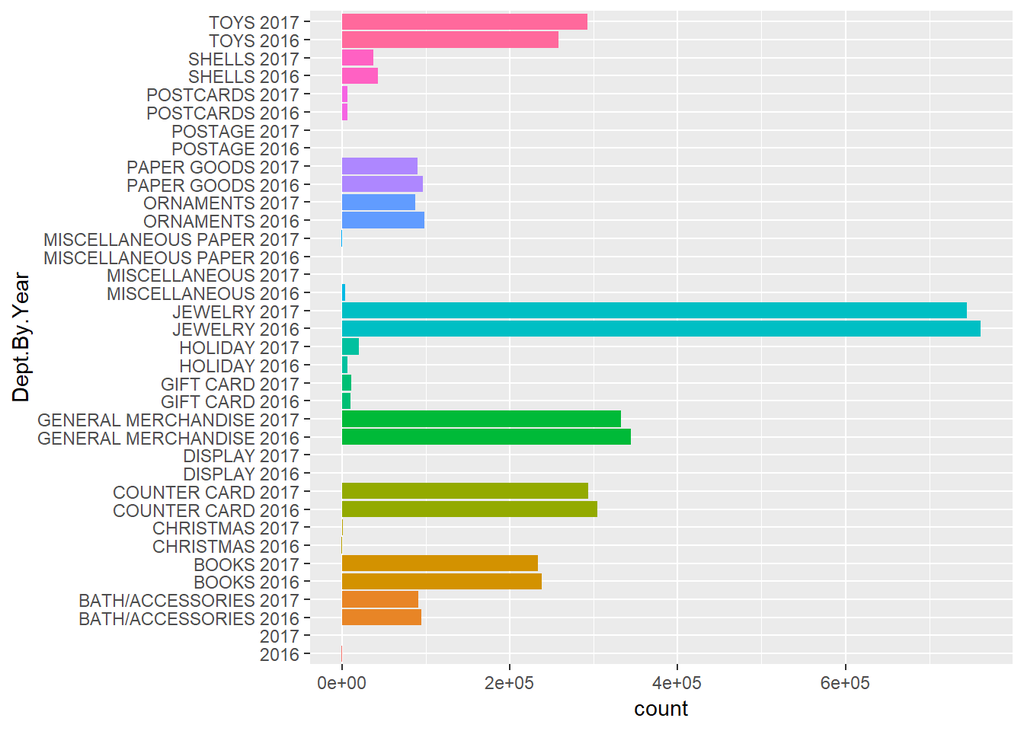

## Remove Very Small Depts

Removed the following categories: “POSTAGE”, “MISCELLANEOUS PAPER”, “MISCELLANEOUS”, “GIFT CARD”, “DISPLAY”

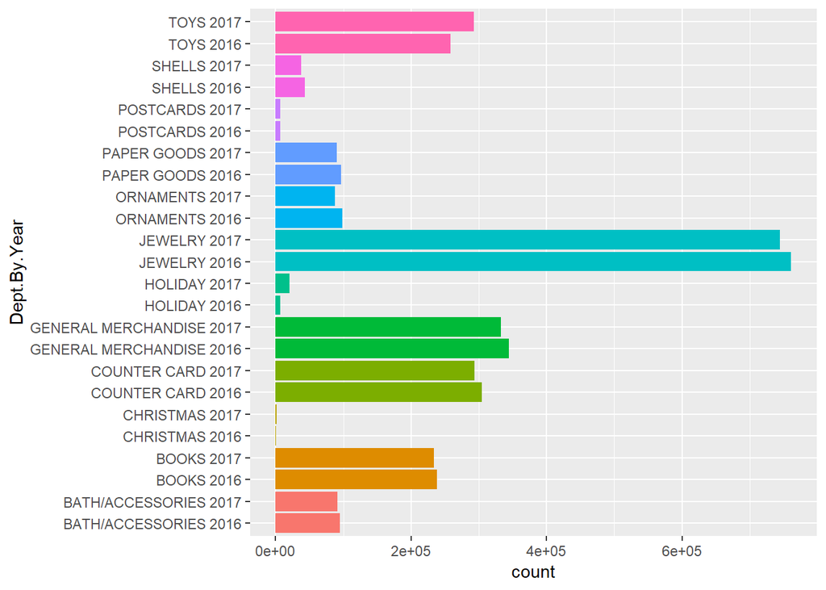

### Jewelry by Category

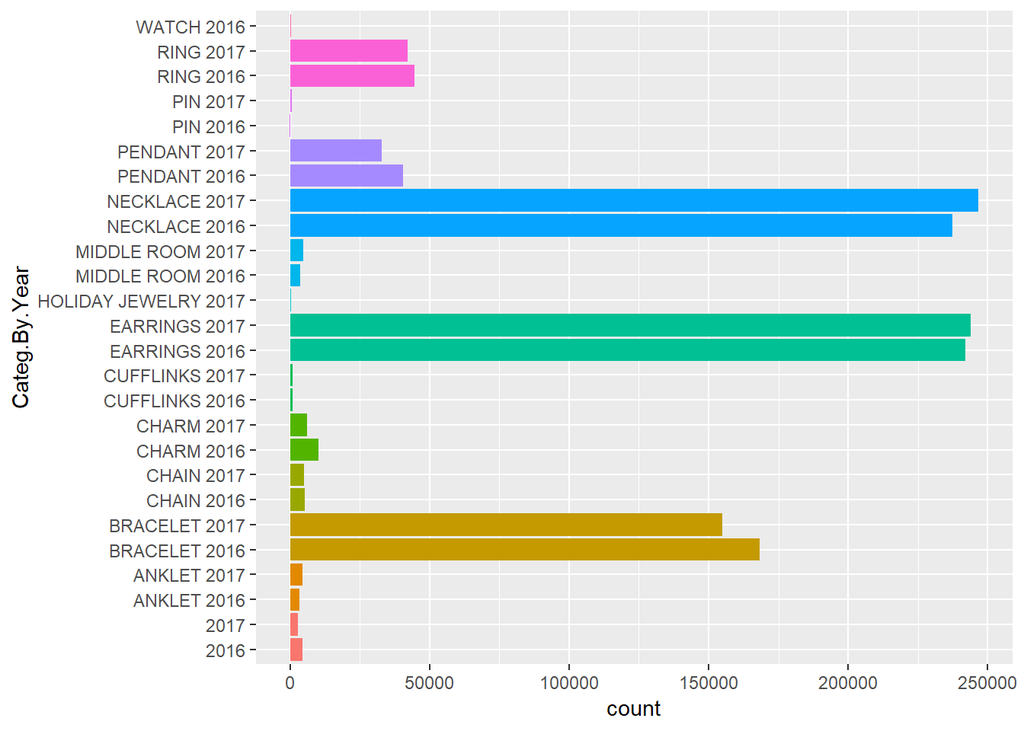

### General Merchandise by Category

The Categories HOUSEWARES, CRAFTS, and ART GLASS were the highest for General Merchandise. Housewares also grew substantially over last year, as did PERS ACCES/BAGS/POUCHES.

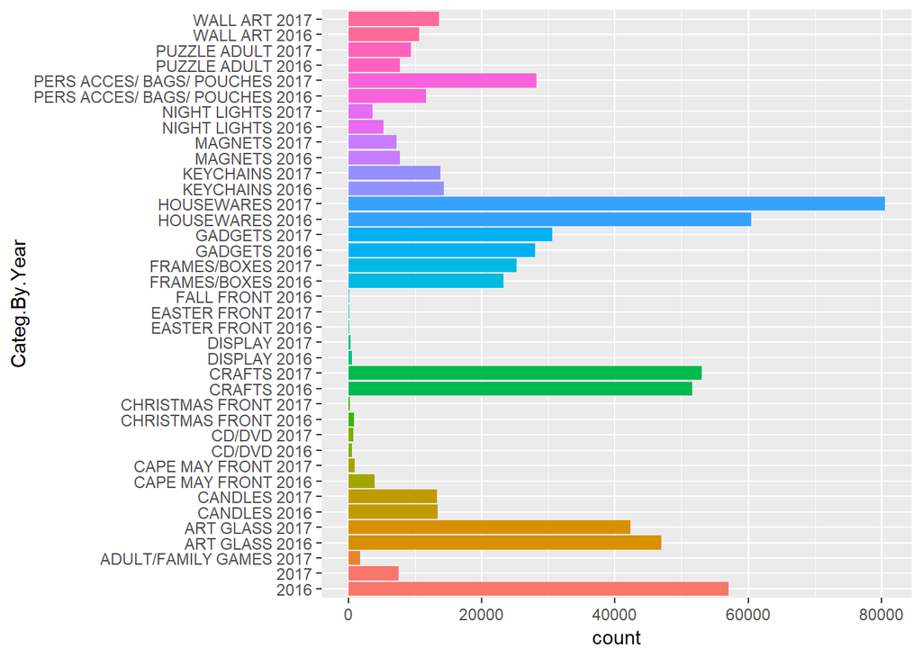

### Counter Card by Category

BIRTHDAY is the largest category by far but saw a slight decline.

The second highest is BLANK cards which also saw an increase in 2017

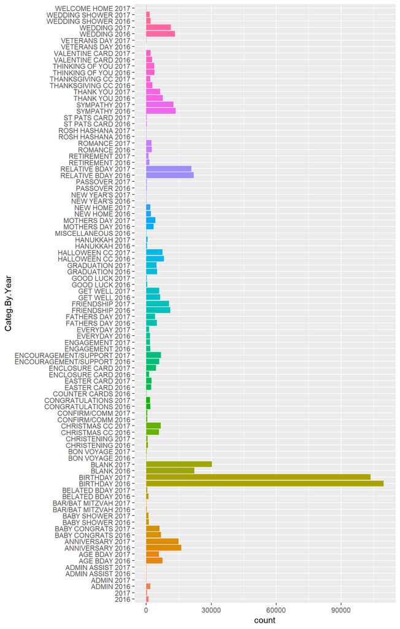

### Toys by Category

IMAGINATIVE PLAY was the top toy category last year and it has continued to an even bigger year as top seller again in 2017.

PLUSH similarly was a really big seller last year (#2) and saw growth on top of that.

Other Categories with big growth were CREATIVE LEARNING, BABY, OUTDOOR FUN.

Notable declines occurred in PUZZLES, PUPPETS, and FINGER PUPPETS

Note that there were more uncategorized TOYS purchases in 2016, so that likely inflates some of the 2017 categories

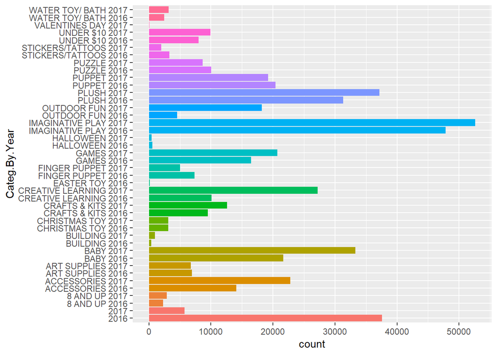

### Books by Category

TOY BOOK HARDBACK is the highest in the category and brings in roughly $80K per year

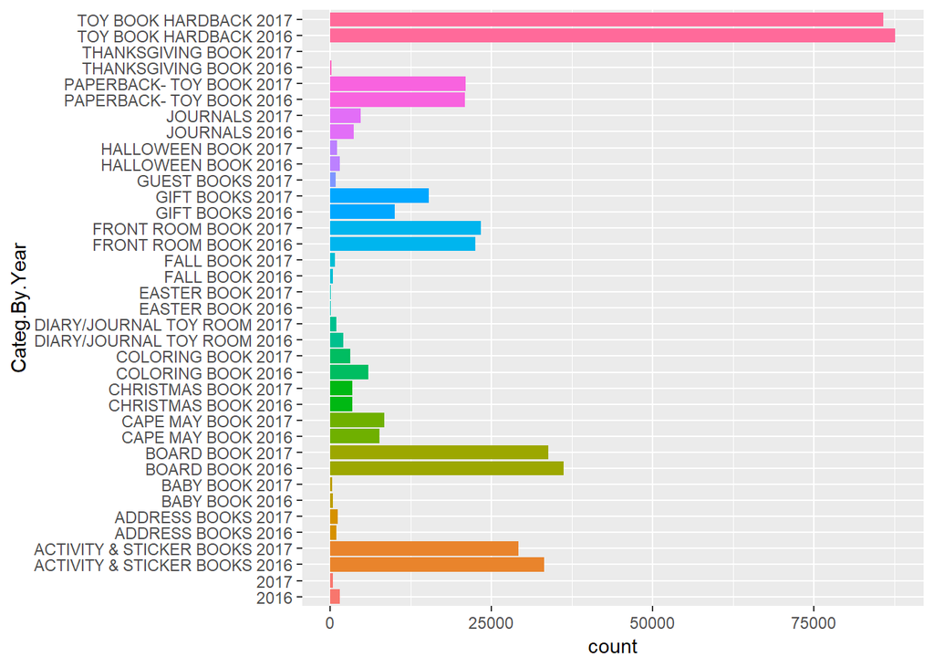